# cc_customer_segmentation_revised

**Project Overview**

This notebook outlines our team’s approach to customer segmentation using the cleaned credit card dataset. We applied clustering techniques (primarily KMeans) to uncover meaningful customer groups that support business strategies in marketing, risk management, and customer engagement.

Key objectives of this notebook include:

- Preprocessing data for clustering
- Identifying the optimal number of clusters (k)
- Profiling customer segments (broad vs. granular)
- Providing actionable recommendations for business teams

This work reflects a collaborative effort to transform raw customer data into actionable insights.

**Table of Contents**

1. Data Preparation
   - Cleaning and preprocessing
   - Feature scaling
2. Cluster Evaluation
   - Elbow Method
   - Silhouette Score & Davies–Bouldin Index
3. Results & Interpretation
   - K=3 (broad segmentation)
   - K=7 (granular segmentation)
4. Recommendations

|  | cust_id | balance | balance_frequency | purchases | oneoff_purchases | installments_purchases | cash_advance | purchases_frequency | oneoff_purchases_frequency | purchases_installments_frequency | cash_advance_frequency | cash_advance_trx | purchases_trx | credit_limit | payments | minimum_payments | prc_full_payment | tenure |
| --- | --- | --- | --- | --- | --- | --- | --- | --- | --- | --- | --- | --- | --- | --- | --- | --- | --- | --- |
| 0 | C10001 | 40.900749 | 0.818182 | 95.40 | 0.00 | 95.4 | 0.000000 | 0.166667 | 0.000000 | 0.083333 | 0.000000 | 0 | 2 | 1000.0 | 201.802084 | 139.509787 | 0.000000 | 12 |
| 1 | C10002 | 3202.467416 | 0.909091 | 0.00 | 0.00 | 0.0 | 6442.945483 | 0.000000 | 0.000000 | 0.000000 | 0.250000 | 4 | 0 | 7000.0 | 4103.032597 | 1072.340217 | 0.222222 | 12 |
| 2 | C10003 | 2495.148862 | 1.000000 | 773.17 | 773.17 | 0.0 | 0.000000 | 1.000000 | 1.000000 | 0.000000 | 0.000000 | 0 | 12 | 7500.0 | 622.066742 | 627.284787 | 0.000000 | 12 |
| 3 | C10004 | 1666.670542 | 0.636364 | 1499.00 | 1499.00 | 0.0 | 205.788017 | 0.083333 | 0.083333 | 0.000000 | 0.083333 | 1 | 1 | 7500.0 | 0.000000 | 312.343947 | 0.000000 | 12 |
| 4 | C10005 | 817.714335 | 1.000000 | 16.00 | 16.00 | 0.0 | 0.000000 | 0.083333 | 0.083333 | 0.000000 | 0.000000 | 0 | 1 | 1200.0 | 678.334763 | 244.791237 | 0.000000 | 12 |

|  | balance | balance_frequency | purchases | oneoff_purchases | installments_purchases | cash_advance | purchases_frequency | oneoff_purchases_frequency | purchases_installments_frequency | cash_advance_frequency | cash_advance_trx | purchases_trx | credit_limit | payments | minimum_payments | prc_full_payment | tenure |
| --- | --- | --- | --- | --- | --- | --- | --- | --- | --- | --- | --- | --- | --- | --- | --- | --- | --- |
| 0 | 40.900749 | 0.818182 | 95.40 | 0.00 | 95.4 | 0.000000 | 0.166667 | 0.000000 | 0.083333 | 0.000000 | 0 | 2 | 1000.0 | 201.802084 | 139.509787 | 0.000000 | 12 |
| 1 | 3202.467416 | 0.909091 | 0.00 | 0.00 | 0.0 | 6442.945483 | 0.000000 | 0.000000 | 0.000000 | 0.250000 | 4 | 0 | 7000.0 | 4103.032597 | 1072.340217 | 0.222222 | 12 |
| 2 | 2495.148862 | 1.000000 | 773.17 | 773.17 | 0.0 | 0.000000 | 1.000000 | 1.000000 | 0.000000 | 0.000000 | 0 | 12 | 7500.0 | 622.066742 | 627.284787 | 0.000000 | 12 |
| 3 | 1666.670542 | 0.636364 | 1499.00 | 1499.00 | 0.0 | 205.788017 | 0.083333 | 0.083333 | 0.000000 | 0.083333 | 1 | 1 | 7500.0 | 0.000000 | 312.343947 | 0.000000 | 12 |
| 4 | 817.714335 | 1.000000 | 16.00 | 16.00 | 0.0 | 0.000000 | 0.083333 | 0.083333 | 0.000000 | 0.000000 | 0 | 1 | 1200.0 | 678.334763 | 244.791237 | 0.000000 | 12 |

```
[[-0.73198937 -0.24943448 -0.42489974 ... -0.3024     -0.52555097
   0.36067954]
 [ 0.78696085  0.13432467 -0.46955188 ...  0.09749953  0.2342269
   0.36067954]
 [ 0.44713513  0.51808382 -0.10766823 ... -0.0932934  -0.52555097
   0.36067954]
 ...
 [-0.7403981  -0.18547673 -0.40196519 ... -0.32687479  0.32919999
  -4.12276757]
 [-0.74517423 -0.18547673 -0.46955188 ... -0.33830497  0.32919999
  -4.12276757]
 [-0.57257511 -0.88903307  0.04214581 ... -0.3243581  -0.52555097
  -4.12276757]]
```

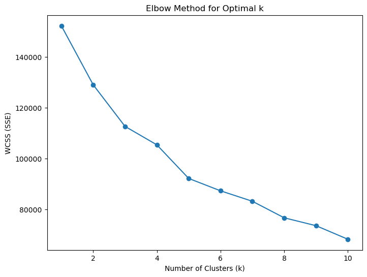

```
    k  Silhouette Score  Davies-Bouldin Index
0   2          0.279540              1.800894
1   3          0.206718              1.659387
2   4          0.166460              1.572081
3   5          0.192566              1.468162
4   6          0.192292              1.592589
5   7          0.215279              1.435278
6   8          0.203637              1.457283
7   9          0.203756              1.547890
8  10          0.211647              1.421519
```

**Clustering Results and Metrics**

Our team compared clustering performance across multiple k values using both the **Silhouette Score** (higher is better for separation) and the **Davies–Bouldin Index** (lower is better for compactness). The results are summarized below:

| k | Silhouette Score | Davies–Bouldin Index |
| --- | --- | --- |
| 2 | **0.2795** | 1.8009 |
| 3 | 0.2067 | 1.6594 |
| 4 | 0.1665 | 1.5721 |
| 5 | 0.1926 | 1.4682 |
| 6 | 0.1923 | 1.5926 |
| 7 | 0.2153 | **1.4353** |
| 8 | 0.2036 | 1.4573 |
| 9 | 0.2038 | 1.5479 |
| 10 | 0.2116 | **1.4215** |

**Team interpretation:**

- **k=2** gives the clearest separation but oversimplifies customer behavior.
- **k=3** aligns with the Elbow Method and provides a reasonable balance of interpretability.
- **k=7** and **k=10** show stronger compactness (lowest DBI), with nuanced clusters.

**Team recommendation:**

- For **strategic simplicity**: use **k=3** (broad segmentation).
- For **granular insights and targeted strategies**: use **k=7**.
- Avoid k=10, as 10 segments may not be practical for business implementation.

|  | Cluster | Count | balance_mean | balance_frequency_mean | purchases_mean | oneoff_purchases_mean | installments_purchases_mean | cash_advance_mean | purchases_frequency_mean | oneoff_purchases_frequency_mean | purchases_installments_frequency_mean | cash_advance_frequency_mean | cash_advance_trx_mean | purchases_trx_mean | credit_limit_mean | payments_mean | minimum_payments_mean | prc_full_payment_mean | tenure_mean | balance_median | balance_frequency_median | purchases_median | oneoff_purchases_median | installments_purchases_median | cash_advance_median | purchases_frequency_median | oneoff_purchases_frequency_median | purchases_installments_frequency_median | cash_advance_frequency_median | … |
| --- | --- | --- | --- | --- | --- | --- | --- | --- | --- | --- | --- | --- | --- | --- | --- | --- | --- | --- | --- | --- | --- | --- | --- | --- | --- | --- | --- | --- | --- | --- |
| K=3 | 0 | 1244 | 4540.78 | 0.97 | 577.33 | 362.96 | 214.45 | 4506.32 | 0.29 | 0.14 | 0.19 | 0.48 | 14.25 | 8.36 | 7458.28 | 3581.20 | 2090.95 | 0.04 | 11.39 | 4183.82 | 1.00 | 79.94 | 0.00 | 0.00 | 3635.00 | 0.08 | 0.00 | 0.00 | 0.50 | … |
|  | 1 | 4557 | 942.29 | 0.79 | 302.35 | 207.64 | 95.01 | 529.77 | 0.24 | 0.09 | 0.15 | 0.10 | 1.91 | 3.99 | 3221.34 | 927.73 | 539.41 | 0.09 | 11.40 | 645.41 | 1.00 | 125.00 | 0.00 | 0.00 | 48.46 | 0.17 | 0.00 | 0.00 | 0.08 | … |
|  | 2 | 3149 | 1289.08 | 0.97 | 2185.67 | 1239.93 | 946.12 | 235.28 | 0.93 | 0.39 | 0.75 | 0.04 | 0.84 | 32.73 | 5165.47 | 2168.61 | 794.76 | 0.29 | 11.74 | 530.57 | 1.00 | 1325.21 | 460.89 | 583.95 | 0.00 | 1.00 | 0.25 | 0.90 | 0.00 | … |
| K=7 | 0 | 991 | 4819.82 | 0.97 | 519.10 | 332.22 | 186.98 | 4911.86 | 0.28 | 0.14 | 0.18 | 0.51 | 15.62 | 7.93 | 7955.50 | 3873.78 | 1662.45 | 0.04 | 11.63 | 4487.99 | 1.00 | 98.40 | 0.00 | 0.00 | 4014.66 | 0.08 | 0.00 | 0.00 | 0.50 | … |
|  | 1 | 1113 | 127.51 | 0.84 | 1292.03 | 641.75 | 650.38 | 58.03 | 0.78 | 0.28 | 0.60 | 0.01 | 0.16 | 19.68 | 5018.40 | 1540.71 | 179.27 | 0.80 | 11.78 | 76.06 | 1.00 | 824.50 | 30.00 | 428.44 | 0.00 | 0.92 | 0.08 | 0.67 | 0.00 | … |
|  | 2 | 2417 | 1426.59 | 0.95 | 1439.48 | 752.33 | 687.48 | 321.91 | 0.89 | 0.34 | 0.72 | 0.06 | 1.15 | 26.16 | 4425.74 | 1555.24 | 756.76 | 0.06 | 11.92 | 961.39 | 1.00 | 1027.28 | 357.90 | 475.36 | 0.00 | 1.00 | 0.25 | 0.83 | 0.00 | … |
|  | 3 | 55 | 3930.51 | 0.99 | 778.72 | 153.53 | 625.19 | 889.92 | 0.45 | 0.04 | 0.41 | 0.10 | 2.93 | 15.55 | 4181.82 | 1380.41 | 22810.69 | 0.00 | 11.91 | 3345.31 | 1.00 | 288.39 | 0.00 | 101.00 | 19.35 | 0.33 | 0.00 | 0.17 | 0.08 | … |
|  | 4 | 659 | 835.60 | 0.77 | 391.47 | 254.06 | 137.86 | 1066.40 | 0.40 | 0.12 | 0.27 | 0.19 | 3.11 | 4.99 | 2443.63 | 602.06 | 344.23 | 0.14 | 7.33 | 460.08 | 0.86 | 165.50 | 0.00 | 0.00 | 419.34 | 0.29 | 0.00 | 0.00 | 0.14 | … |
|  | 5 | 236 | 4106.10 | 0.98 | 10001.61 | 6718.37 | 3285.79 | 692.69 | 0.94 | 0.76 | 0.79 | 0.07 | 2.21 | 104.60 | 10657.42 | 9494.21 | 2069.32 | 0.31 | 11.95 | 2954.27 | 1.00 | 8160.13 | 4941.99 | 2540.50 | 0.00 | 1.00 | 0.87 | 1.00 | 0.00 | … |
|  | 6 | 3479 | 1120.93 | 0.82 | 254.62 | 195.18 | 59.66 | 613.80 | 0.16 | 0.08 | 0.08 | 0.12 | 2.27 | 2.83 | 3363.59 | 1001.89 | 550.74 | 0.04 | 11.88 | 891.33 | 1.00 | 71.75 | 0.00 | 0.00 | 139.11 | 0.08 | 0.00 | 0.00 | 0.08 | … |

**Customer Segment Profiling**

Following the clustering analysis, our team focused on profiling customers under **k=3** and **k=7**, as these represent the most practical balance between business usability and cluster quality. While k=10 showed strong metrics, we determined it would be operationally challenging to manage that many segments.

#### **K=3 (Broad Segmentation)**

- **Cluster 0 (1244 customers):** High balances and cash advances, low payment ratios → *Revolvers / heavy credit users*.
- **Cluster 1 (4557 customers):** Low balances, low purchases, moderate credit limits → *Low engagement / low revenue customers*.
- **Cluster 2 (3149 customers):** High purchase frequency, low cash advances → *High engagement spenders / transactors*.

📌 *K=3 provides clear, broad categories that help frame overall customer behavior.*

#### **K=7 (Granular Segmentation)**

**Final recommendation:** The project team recommends proceeding with **k=7** for practical segmentation and targeted business actions, while using **k=3** as a simplified view when broad categorization is sufficient.